# Form over function: can we predict the manner in which people exercise?

Ben de Haan

6/25/2021

## Synopsis

### Loading the data and reading in data

Data was downloaded from the URLs specified below and saved to respective comma-separated value files. Further documentation can be found on `http://web.archive.org/web/20161224072740/http:/groupware.les.inf.puc-rio.br/har`.

Dataset credits: Velloso, E.; Bulling, A.; Gellersen, H.; Ugulino, W.; Fuks, H. Qualitative Activity Recognition of Weight Lifting Exercises. Proceedings of 4th International Conference in Cooperation with SIGCHI (Augmented Human ’13) . Stuttgart, Germany: ACM SIGCHI, 2013.

```r
urlTrain <- "https://d396qusza40orc.cloudfront.net/predmachlearn/pml-training.csv"
download.file(urlTrain, destfile = "train.csv")
urlTest <- "https://d396qusza40orc.cloudfront.net/predmachlearn/pml-testing.csv"
download.file(urlTest, destfile = "test.csv")
```

```r
training = read.csv("train.csv")
testing = read.csv("test.csv")
```

It’s important to not explore the test sets, as that could introduce further bias in creating an algorithm. Let’s first get an understanding of what’s in the dataset.

```r
length(training)
```

```
## [1] 160
```

```r
nrow(training)
```

```
## [1] 19622
```

```r
training %>%
  summarise_all(class) %>%
    gather
```

```
##                          key     value
## 1                          X   integer
## 2                  user_name character
## 3       raw_timestamp_part_1   integer
## 4       raw_timestamp_part_2   integer
## 5             cvtd_timestamp character
## 6                 new_window character
## 7                 num_window   integer
## 8                  roll_belt   numeric
## 9                 pitch_belt   numeric
## 10                  yaw_belt   numeric
## 11          total_accel_belt   integer
## 12        kurtosis_roll_belt character
## 13       kurtosis_picth_belt character
## 14         kurtosis_yaw_belt character
```

[output cut: 146 more lines]

Variables user_name and classe should be factors, so let’s fix that.

```r
training$classe <- as.factor(training$classe)
training$user_name <- as.factor(training$user_name)

# As per exception, we should fix this in testing as well to prevent a type mismatch in prediction.
testing$user_name <- as.factor(testing$user_name)
```

Let’s also see about missing values.

```r
sum_na <- function (x) {
  sum(is.na(x))
}

lapply(training,sum_na)
```

[output not shown]

[output cut: 424 more lines]

```
##
## $accel_forearm_z
## [1] 0
##
## $magnet_forearm_x
## [1] 0
##
## $magnet_forearm_y
## [1] 0
##
## $magnet_forearm_z
## [1] 0
##
## $classe
## [1] 0
```

## Results

### Exploratory data analysis

In order to understand the data I have, I start out with exploring what’s in there and spotting potential differences.

There are five classes the dataset, corresponding to ‘right’ or ‘wrong’ ways to perform an exercise. In total, there are 160 variables telling us something about the user, sensor reading, and classe.

```
## # A tibble: 5 x 7
##   `as.factor(classe)`    min     q1 median   mean    q3   max
##   <fct>                <dbl>  <dbl>  <dbl>  <dbl> <dbl> <dbl>
## 1 A                    -63.8   14.1   23.5  29.7   46.8  97.3
## 2 B                   -179   -140.   114    37.7  138.  179
## 3 C                   -177    139    146   115.   150   179
## 4 D                   -179   -145   -129    -1.72 146   179
## 5 E                   -180   -151    137    28.3  145   179
```

To gain some additional insight, we can plot the smoothed arm roll per user per classe over time. This gives us a rough idea of possible trends and differences for this specific measurement.

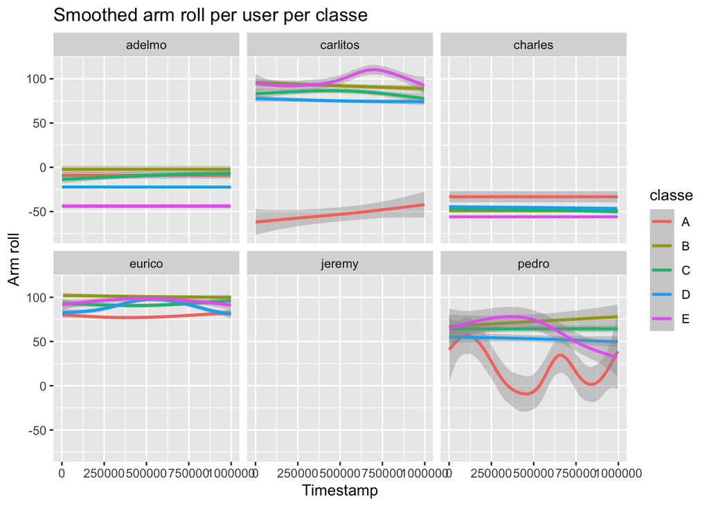

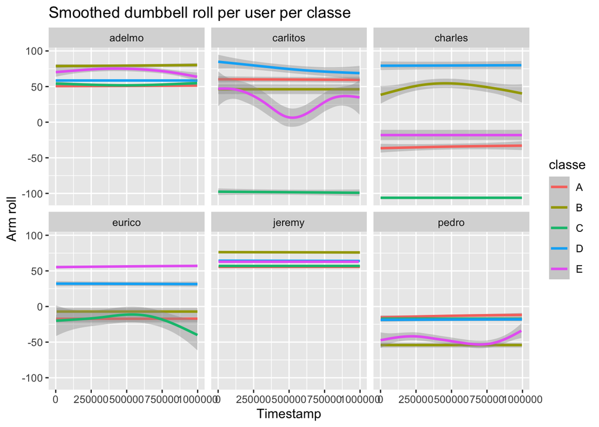

There seem to be some differences in sensor readings per classe per user. A possibly problematic component for cross-validation is that time-series data is interlinked heavily per user. This means we have to make a choice in tuning the model to a specific user, or making it more general.

Since these devices are most useful in personal recommendations, my approach is to tune a model to a specific user. This means we include the user name variable in learning.

There are definitely some variables that we should exclude to prevent overfitting or making our model too complex. These include X (the observation number), the cvtd_timestamp, new_window, num_window. The raw_timestamp_part_1 also doesn’t look too helpful, as this is not granular to a specific part of the exercise. There are also a lot of missing variables for any of the aggregate statistics, so let’s exclude those too.

```r
slim_training <- select(training,
                        -c(
                          X,
                          cvtd_timestamp,
                          new_window,
                          num_window,
                          raw_timestamp_part_1,
                          starts_with("avg"),
                          starts_with("max"),
                          starts_with("min"),
                          starts_with("stddev"),
                          starts_with("var"),
                          starts_with("amplitude"),
                          starts_with("kurtosis"),
                          starts_with("skewness")
                          ))
```

### Testing various algorithms

Since we’re trying to predict a class, we should use an algorithm suitable for classification. Decision trees (and especially a random forest) fit this outcome.

Let’s not forget to set a seed and generic approach for cross-validation first.

```r
set.seed(62656) # hex-encoded "Ben" leaving out the "e" at the end
cv <- trainControl(method = "cv", number=5)
```

```r
fit <- train(classe~.,
             data = slim_training,
             method = "rpart",
             trControl = cv)
print(fit)
```

```
## CART
##
## 19622 samples
##    54 predictor
##     5 classes: 'A', 'B', 'C', 'D', 'E'
##
## No pre-processing
## Resampling: Cross-Validated (5 fold)
## Summary of sample sizes: 15696, 15698, 15699, 15698, 15697
## Resampling results across tuning parameters:
##
##   cp          Accuracy   Kappa
##   0.03567868  0.5044358  0.35291517
##   0.05998671  0.4686481  0.29623605
##   0.11515454  0.3493084  0.09889146
##
## Accuracy was used to select the optimal model using the largest value.
## The final value used for the model was cp = 0.03567868.
```

```r
prediction_cart <- predict(fit, training)
confusionMatrix(training$classe,prediction_cart)
```

```
## Confusion Matrix and Statistics
##
##           Reference
## Prediction    A    B    C    D    E
##          A 5080   81  405    0   14
##          B 1581 1286  930    0    0
##          C 1587  108 1727    0    0
##          D 1449  568 1199    0    0
##          E  524  486  966    0 1631
##
## Overall Statistics
##
##                Accuracy : 0.4956
##                  95% CI : (0.4885, 0.5026)
##     No Information Rate : 0.5209
##     P-Value [Acc > NIR] : 1
##
##                   Kappa : 0.3407
##
##  Mcnemar's Test P-Value : NA
##
## Statistics by Class:
##
##                      Class: A Class: B Class: C Class: D Class: E
## Sensitivity            0.4970  0.50850  0.33040       NA  0.99149
## Specificity            0.9468  0.85310  0.88225   0.8361  0.89008
## Pos Pred Value         0.9104  0.33869  0.50468       NA  0.45218
## Neg Pred Value         0.6339  0.92145  0.78395       NA  0.99913
## Prevalence             0.5209  0.12889  0.26638   0.0000  0.08383
## Detection Rate         0.2589  0.06554  0.08801   0.0000  0.08312
## Detection Prevalence   0.2844  0.19351  0.17440   0.1639  0.18382
## Balanced Accuracy      0.7219  0.68080  0.60633       NA  0.94079
```

The ordinary classification tree yields an accuracy of ~49.5%.

```r
fit2 <-train(classe~.,
             data=slim_training,
             method="rf",
             trControl=cv,
             allowParallel=TRUE)
print(fit2)
```

```
## Random Forest
##
## 19622 samples
##    54 predictor
##     5 classes: 'A', 'B', 'C', 'D', 'E'
##
## No pre-processing
## Resampling: Cross-Validated (5 fold)
## Summary of sample sizes: 15697, 15698, 15698, 15698, 15697
## Resampling results across tuning parameters:
##
##   mtry  Accuracy   Kappa
##    2    0.9932219  0.9914253
##   30    0.9942922  0.9927796
##   58    0.9886351  0.9856225
##
## Accuracy was used to select the optimal model using the largest value.
## The final value used for the model was mtry = 30.
```

```r
prediction_rf <- predict(fit2, training)
confusionMatrix(training$classe,prediction_rf)
```

```
## Confusion Matrix and Statistics
##
##           Reference
## Prediction    A    B    C    D    E
##          A 5580    0    0    0    0
##          B    0 3797    0    0    0
##          C    0    0 3422    0    0
##          D    0    0    0 3216    0
##          E    0    0    0    0 3607
##
## Overall Statistics
##
##                Accuracy : 1
##                  95% CI : (0.9998, 1)
##     No Information Rate : 0.2844
##     P-Value [Acc > NIR] : < 2.2e-16
##
##                   Kappa : 1
##
##  Mcnemar's Test P-Value : NA
##
## Statistics by Class:
##
##                      Class: A Class: B Class: C Class: D Class: E
## Sensitivity            1.0000   1.0000   1.0000   1.0000   1.0000
## Specificity            1.0000   1.0000   1.0000   1.0000   1.0000
## Pos Pred Value         1.0000   1.0000   1.0000   1.0000   1.0000
## Neg Pred Value         1.0000   1.0000   1.0000   1.0000   1.0000
## Prevalence             0.2844   0.1935   0.1744   0.1639   0.1838
## Detection Rate         0.2844   0.1935   0.1744   0.1639   0.1838
## Detection Prevalence   0.2844   0.1935   0.1744   0.1639   0.1838
## Balanced Accuracy      1.0000   1.0000   1.0000   1.0000   1.0000
```

The random forest method yields a near 100% accuracy. This looks like we might be overfitting here, but we don’t know the results for sure until we’ve tried the model on the test set. Let’s predict for it first.

```r
prediction_rf_test <- predict(fit2, testing)
prediction_rf_test
```

```
##  [1] B A B A A E D B A A B C B A E E A B B B
## Levels: A B C D E
```

## Conclusion

After pre-processing and leaving out some of the variables, the random forest looks like an adequate algorithm for this data, yielding a close to 100% accuracy.